# Practical Machine Learning Project

Eugene

18 November 2015

## Data

A seed is set at 2718 for reproducibility. The data is read in from the following locations: [training](https://d396qusza40orc.cloudfront.net/predmachlearn/pml-training.csv) and [test](https://d396qusza40orc.cloudfront.net/predmachlearn/pml-testing.csv). The test data contains many columns that consist entirely of NA values, these are stripped from the dataset. It also contains several columns which are of no use for prediction: stuff like time, data, subject, and problem_id. These are also removed. The final data frame has 52 columns.  
The training data is cleaned so that it has the same columns as the test set, but with the extra column specifying the classe for each observation. The training set is then split into a training set proper and a validation set in a 70/30 ratio respectively.  
The final data is checked to see if there are any NA values that should be imputed. That there are no NA values is found to be TRUE

To investigate how easily the various classes of training behaviour might be separated we plotted sparklines (inspired a little bit by Edward Tufte’s [Beautiful Evidence](http://www.edwardtufte.com/tufte/books_be) book. These sparklines are shown below, stack separated and ordered by mean of increasing parameter. The bottom red line represents classe A. As can be seen, parameters 45 (magnet_arm_y, orange vertical line) and 47 (magnet_arm_x, purple vertical line) seem particularly important to distinguish classe A from the rest. Many of the parameters show little variation from one set to the next and may be of little use as predictors. Overall, however, the variation between these sparklines leads me to be confident that good separation could be achieved.

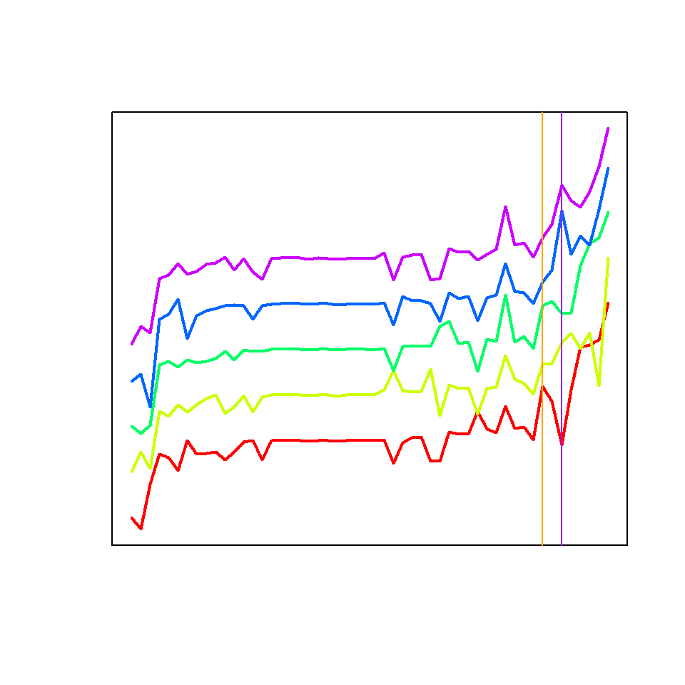

## Processing Speed & Columns of Low Variablility

Fitting predictive models can be computationally heavy and this is certainly true for the problem here with over fifty variables and thousands of measurements. For the most part this was pretty much beyond the meagre computing resources I had available. Also, in the spirit of the course it is more important to be able to try out different models than to have an industrial standard fit. To that end, the number of variables was reduced to manageable levels by selecting only those that showed significant variation across observations. After all, if a parameter doesn’t change much then it doesn’t greatly aide prediction. This selection procedure is done just once on the training set rather than for each stage of cross-validation, so it almost but doesn’t quite meet the selection criterion set out by [Ambroise and McLachlan, 2002](https://www.uvm.edu/~rsingle/stat380/F04/possible/Ambroise+McLachlan-PNAS-2002.pdf).

The plot below shows the ratio of standard deviation to mean for all columns in the training data. A value of 1.5 was arbitrarily chosen to give a manageable number of variables for model fitting. This leaves 10 variables, the ones above the red line. It should be noted that, because of this, subsequent model fits are expected to have high bias and low variance.

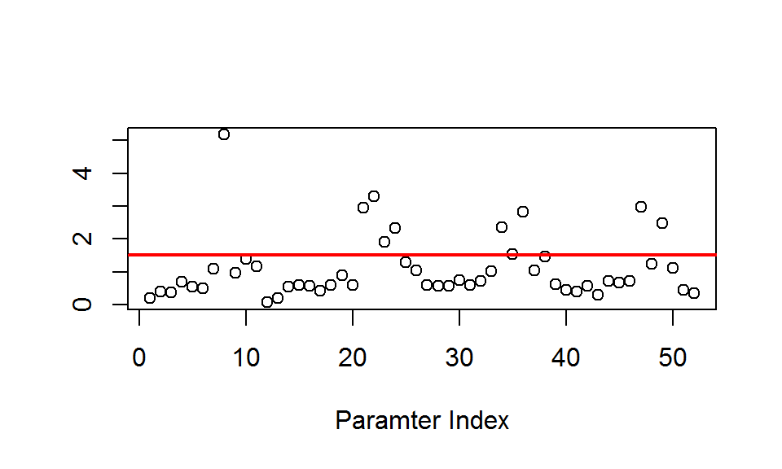

## Models

### tree

To get some idea of how classification trees might work on this data we first ran the trees function. This simply uses [recursive partitioning](https://en.wikipedia.org/wiki/Recursive_partitioni) and is prone to overfitting of the data. For our validation data set it gave an out-of-sample accuracy of 0.4, so not so good. A plot of the tree produced is shown below:

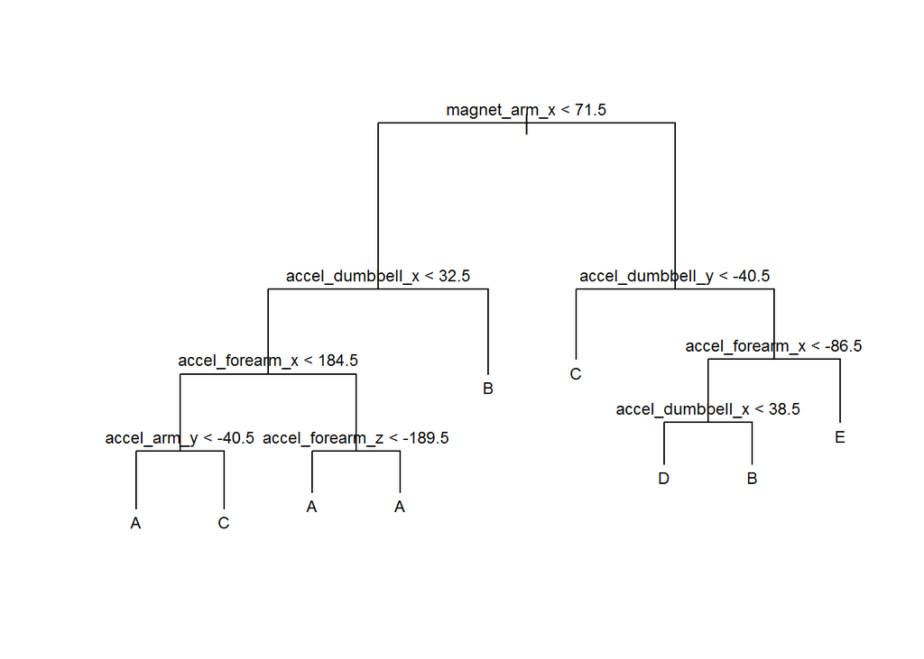

### Random Forest

A more sophisticated approach is to use a [Random Forest](https://en.wikipedia.org/wiki/Random_forest). This tackles the issue of overfitting. In this random forest, cross-validation was chosen with 10 splits. Leave-one-out cross validation was also tried but produced a negligible increase in accuracy and took a great deal longer to compute. The accuracy achieved was 0.925, not bad. The full table is shown in Table 1.

### Gradient Boosting

A Gradient Boosting model was applied to the problem. An interaction depth of 3 was chosen, close to the recommendation of [Hastie](https://web.stanford.edu/~hastie/local.ftp/Springer/OLD/ESLII_print4.pdf). 5-fold cross-validation was used. An accuracy of 0.767 was achieved.

### Naieve Bayes

An accuracy of 0.56 was achieved.

### Linear Discriminant Analysis

An accuracy of 0.418 was achieved.

### Extra Trees Model

ExtraTrees is an extension of the random forest method. Instead of the chosing the best cutting threshold for the feature as random forest does, extraTrees choses the cut randomly. It uses the Gini Index to assess performance. It is also an order of magnitude faster than randomForest. We used the default settings: 500 trees and 1 random cut (increasing the number of random cuts is said to increase the accuracy. This model produced a mesmirising unerring fit to both the training set and the validation set. So the accuracy achieved was 0.995.

## Comparing Models

The table below gives the detection prevalence for different classes across the various models. As we can see, from a strictly accounting basis, ExtraTrees is extraordinary, Random Forest does OK, the rest get progressively worse

|  | True Values | ExtraTrees | Random Forest | Gradient Boosting | Naive Bayes | LDA | tree |
| --- | --- | --- | --- | --- | --- | --- | --- |
| A | 1674 | 1673 | 1700 | 1807 | 1636 | 2426 | 940 |
| B | 1139 | 1145 | 1080 | 960 | 796 | 880 | 273 |
| C | 1026 | 1032 | 1091 | 1145 | 1300 | 664 | 1761 |
| D | 964 | 959 | 963 | 994 | 1440 | 1203 | 1418 |
| E | 1082 | 1076 | 1051 | 979 | 713 | 712 | 1493 |

This next table summarises the in-sample and out-of-sample accuracy of the various models. It also gives an indication of the compute time for each one. Unusally, the oos accuracy is better that the in-sample accuracy for some models, a quirk of the statistics I guess.

|  | In Sample Accuracy | Out of Sample Accuracy | Time Taken | Cross Validation Method |
| --- | --- | --- | --- | --- |
| Extra Trees | 0.995 | 0.995 | NA | Limited Random Subset of Splits |
| Random Forest | 0.914 | 0.925 | 481.75 | CV with 10 cuts |
| Gradient Boost | 0.759 | 0.767 | 132.22 | RepeatedCV |
| Naive Bayes | 0.52 | 0.56 | 68.97 | Default Cross-Validation |
| LDA | 0.426 | 0.418 | 481.75 | Default Cross-Validation |

## Heat Maps

Below is a series of heat maps from four of the models. It is hard to discern any particular pattern in these maps; the same combination of classes seem to pose difficult to all models. Classe A seems to be easy to identify. Classe B is frequently confused with other classes.

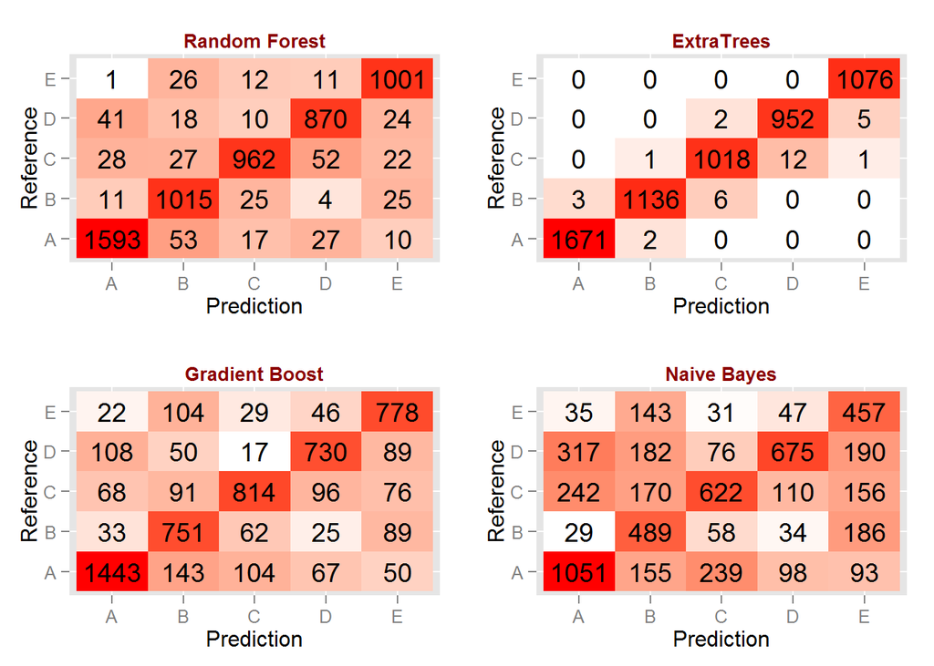

## Confusion Matrices

Just giving some examples of these:

### Extra Trees

```
## Confusion Matrix and Statistics
##
##           Reference
## Prediction    A    B    C    D    E
##          A 1671    3    0    0    0
##          B    2 1136    1    0    0
##          C    0    6 1018    2    0
##          D    0    0   12  952    0
##          E    0    0    1    5 1076
##
## Overall Statistics
##
##                Accuracy : 0.9946
##                  95% CI : (0.9923, 0.9963)
##     No Information Rate : 0.2843
##     P-Value [Acc > NIR] : < 2.2e-16
##
##                   Kappa : 0.9931
##  Mcnemar's Test P-Value : NA
##
## Statistics by Class:
##
##                      Class: A Class: B Class: C Class: D Class: E
## Sensitivity            0.9988   0.9921   0.9864   0.9927   1.0000
## Specificity            0.9993   0.9994   0.9984   0.9976   0.9988
## Pos Pred Value         0.9982   0.9974   0.9922   0.9876   0.9945
## Neg Pred Value         0.9995   0.9981   0.9971   0.9986   1.0000
## Prevalence             0.2843   0.1946   0.1754   0.1630   0.1828
## Detection Rate         0.2839   0.1930   0.1730   0.1618   0.1828
## Detection Prevalence   0.2845   0.1935   0.1743   0.1638   0.1839
## Balanced Accuracy      0.9990   0.9958   0.9924   0.9951   0.9994
```

### Random Forest

```
## Confusion Matrix and Statistics
##
##           Reference
## Prediction    A    B    C    D    E
##          A 1593   11   28   41    1
##          B   53 1015   27   18   26
##          C   17   25  962   10   12
##          D   27    4   52  870   11
##          E   10   25   22   24 1001
##
## Overall Statistics
##
##                Accuracy : 0.9246
##                  95% CI : (0.9175, 0.9312)
##     No Information Rate : 0.2889
##     P-Value [Acc > NIR] : < 2.2e-16
##
##                   Kappa : 0.9045
##  Mcnemar's Test P-Value : 3.756e-14
##
## Statistics by Class:
##
##                      Class: A Class: B Class: C Class: D Class: E
## Sensitivity            0.9371   0.9398   0.8818   0.9034   0.9524
## Specificity            0.9806   0.9742   0.9866   0.9809   0.9832
## Pos Pred Value         0.9516   0.8911   0.9376   0.9025   0.9251
## Neg Pred Value         0.9746   0.9863   0.9735   0.9811   0.9896
## Prevalence             0.2889   0.1835   0.1854   0.1636   0.1786
## Detection Rate         0.2707   0.1725   0.1635   0.1478   0.1701
## Detection Prevalence   0.2845   0.1935   0.1743   0.1638   0.1839
## Balanced Accuracy      0.9589   0.9570   0.9342   0.9422   0.9678
```

### Naive Bayes

```
## Confusion Matrix and Statistics
##
##           Reference
## Prediction    A    B    C    D    E
##          A 1051   29  242  317   35
##          B  155  489  170  182  143
##          C  239   58  622   76   31
##          D   98   34  110  675   47
##          E   93  186  156  190  457
##
## Overall Statistics
##
##                Accuracy : 0.5597
##                  95% CI : (0.5469, 0.5725)
##     No Information Rate : 0.278
##     P-Value [Acc > NIR] : < 2.2e-16
##
##                   Kappa : 0.4454
##  Mcnemar's Test P-Value : < 2.2e-16
##
## Statistics by Class:
##
##                      Class: A Class: B Class: C Class: D Class: E
## Sensitivity            0.6424  0.61432   0.4785   0.4688  0.64095
## Specificity            0.8534  0.87227   0.9119   0.9350  0.87916
## Pos Pred Value         0.6278  0.42932   0.6062   0.7002  0.42237
## Neg Pred Value         0.8611  0.93531   0.8605   0.8445  0.94670
## Prevalence             0.2780  0.13526   0.2209   0.2447  0.12116
## Detection Rate         0.1786  0.08309   0.1057   0.1147  0.07766
## Detection Prevalence   0.2845  0.19354   0.1743   0.1638  0.18386
## Balanced Accuracy      0.7479  0.74330   0.6952   0.7019  0.76006
```